# CSCI E-63C: Final Exam/Project

PC1 vs PC2 plots:

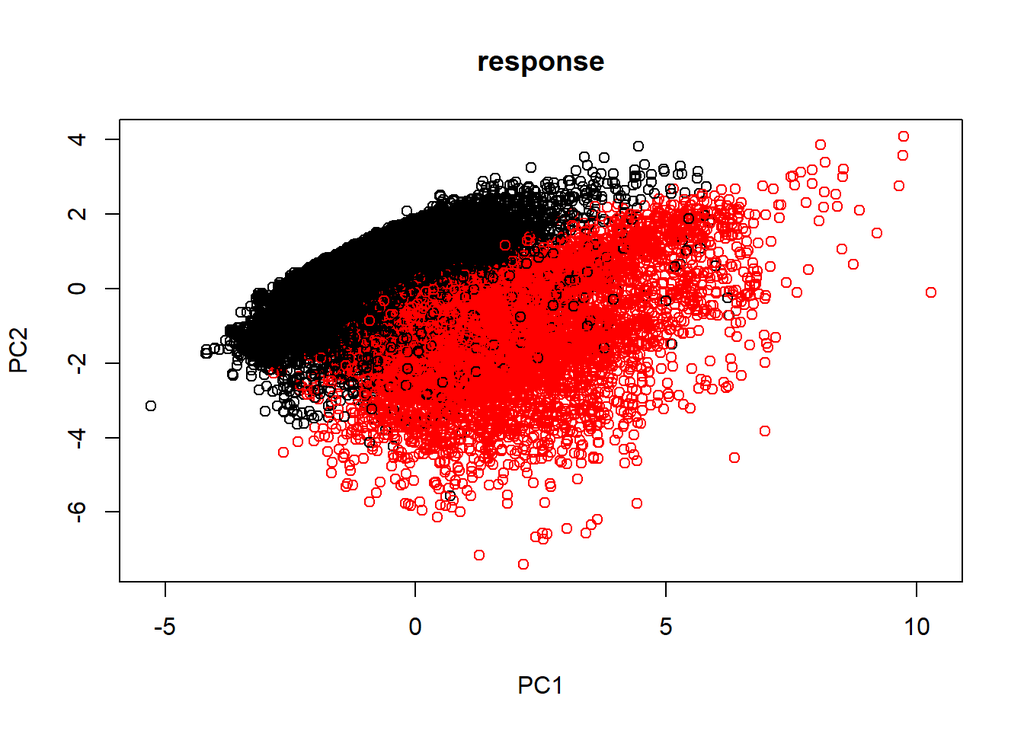

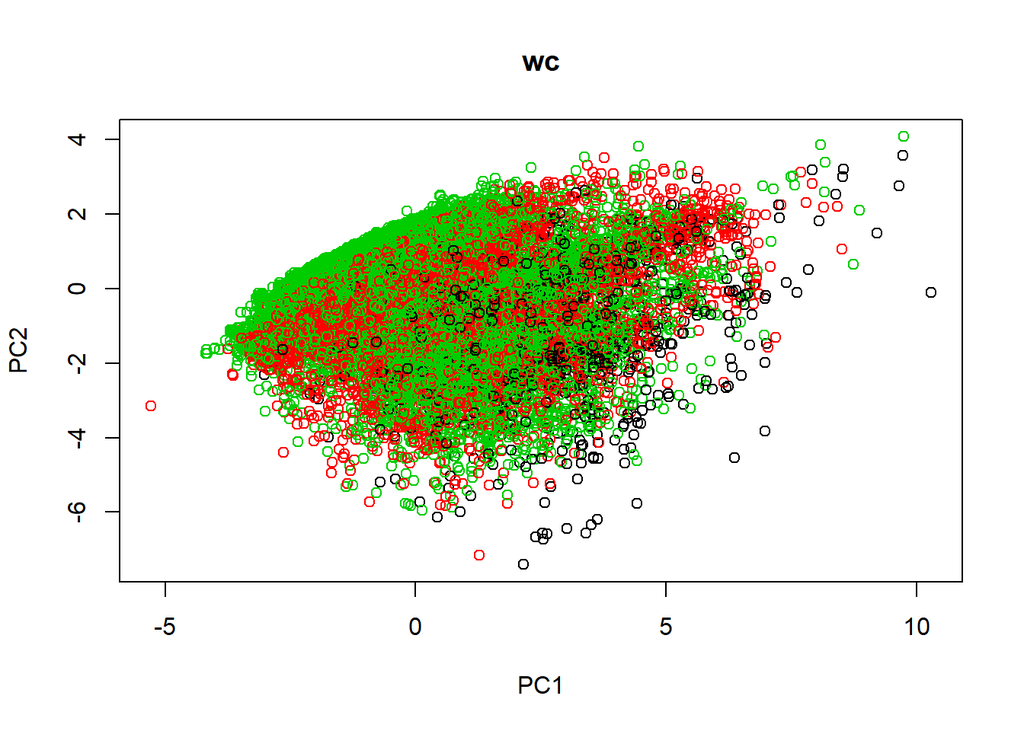

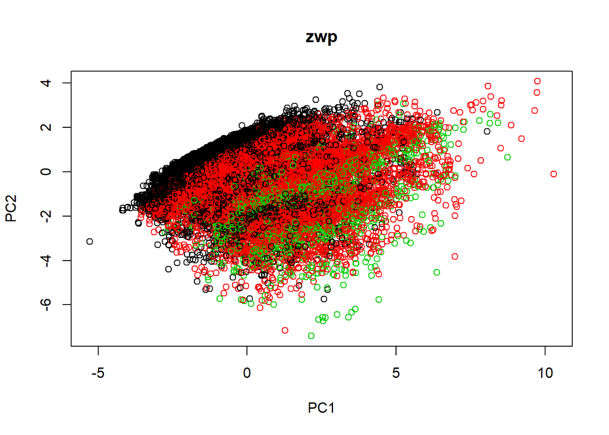

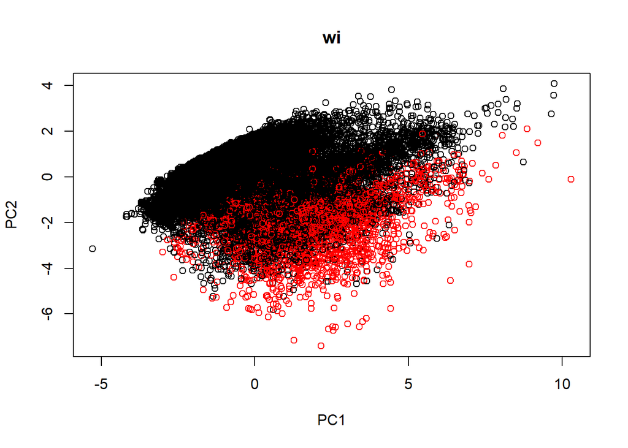

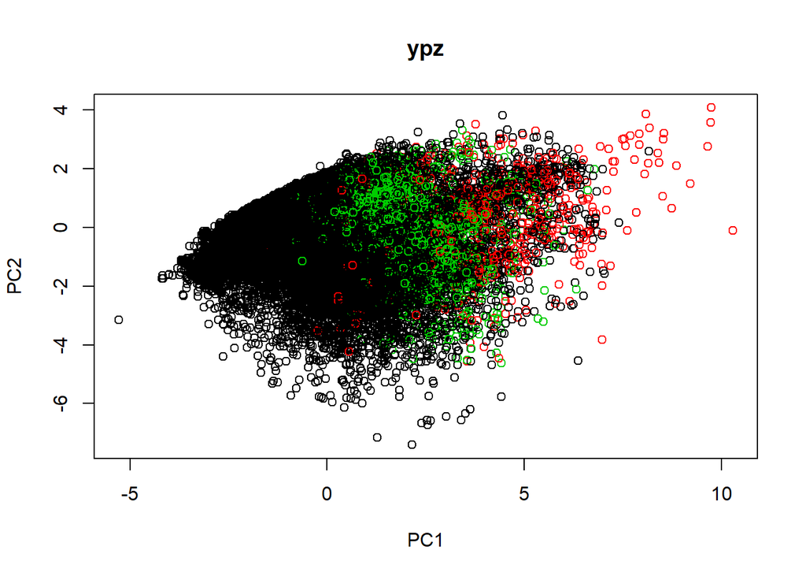

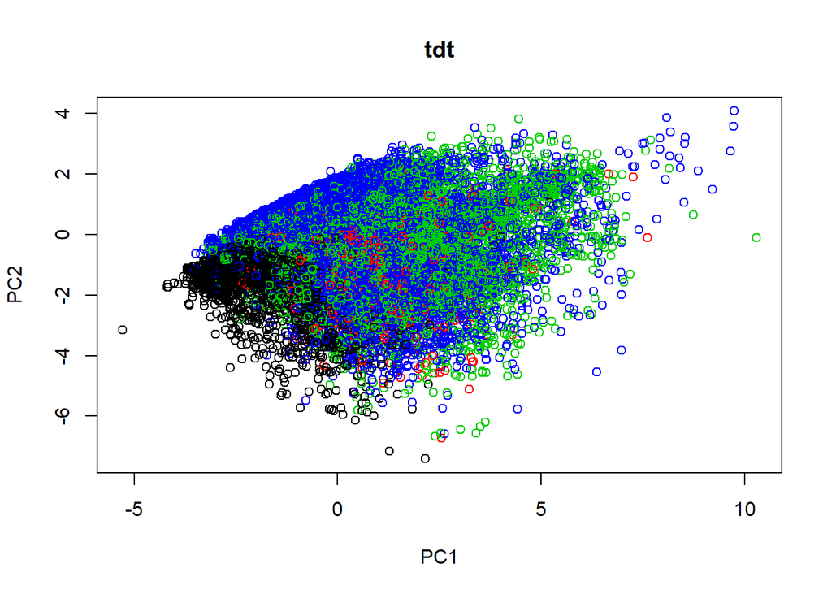

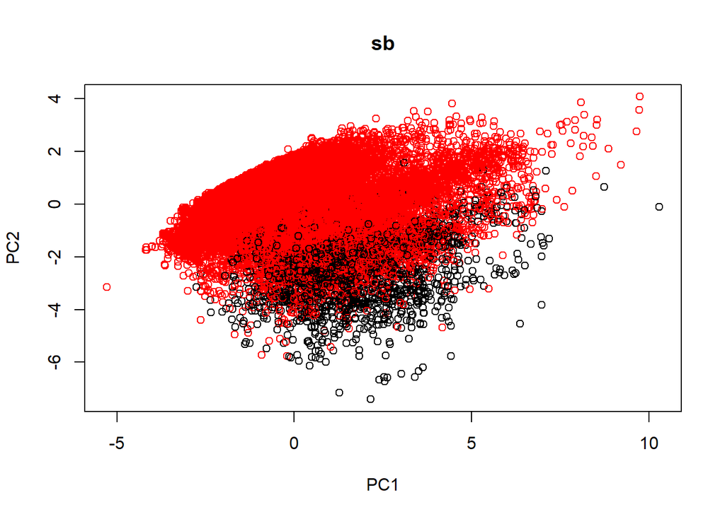

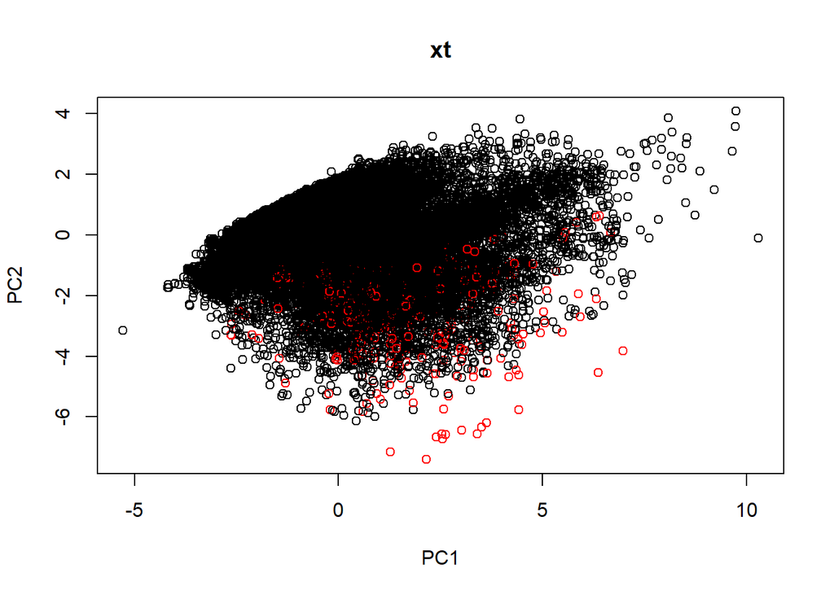

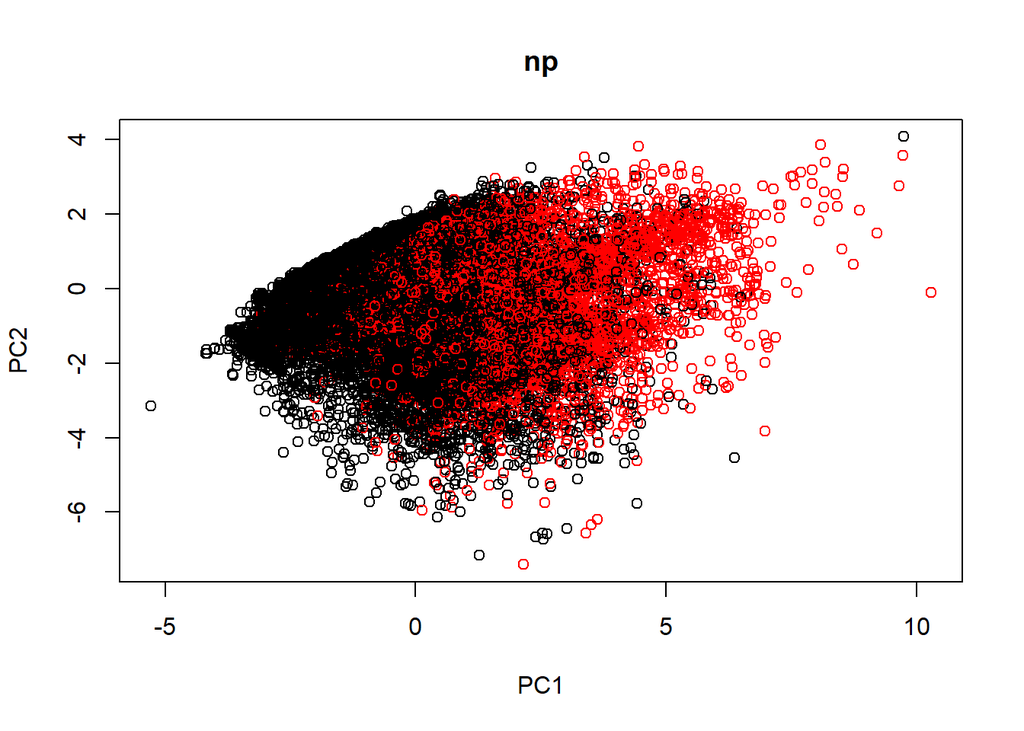

```r
for (i in discrete.vec){
    plot(pca$x[,1:2], col=pca.data[,i], main = i)
}
```

PC2 vs PC3 plots:

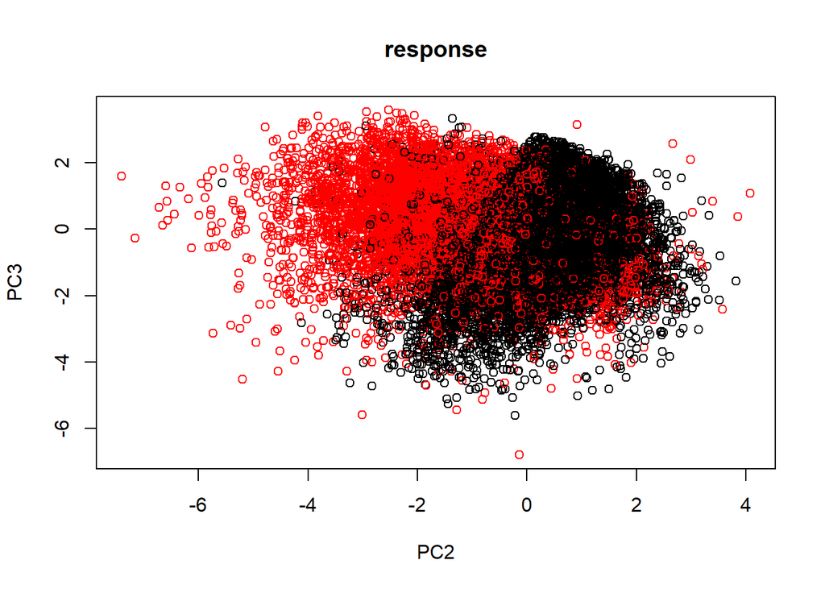

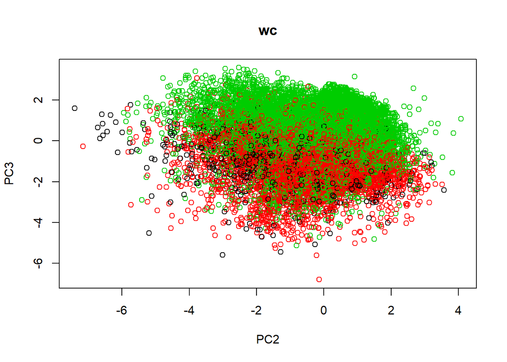

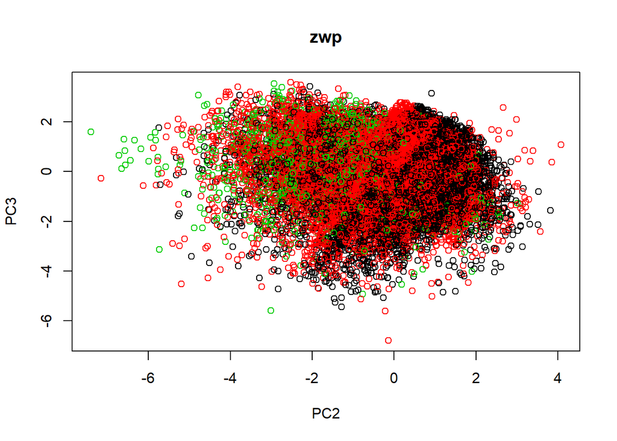

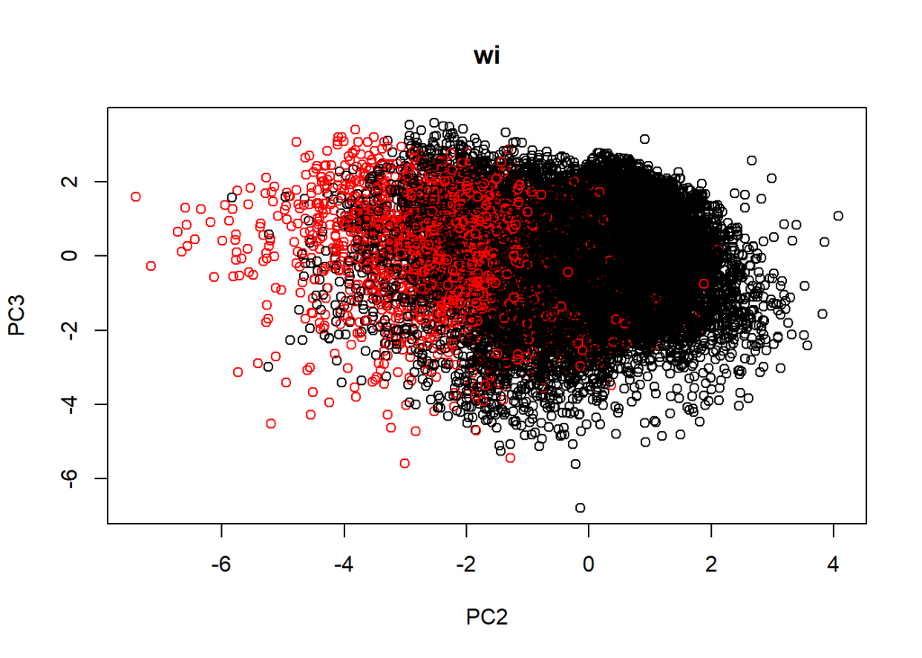

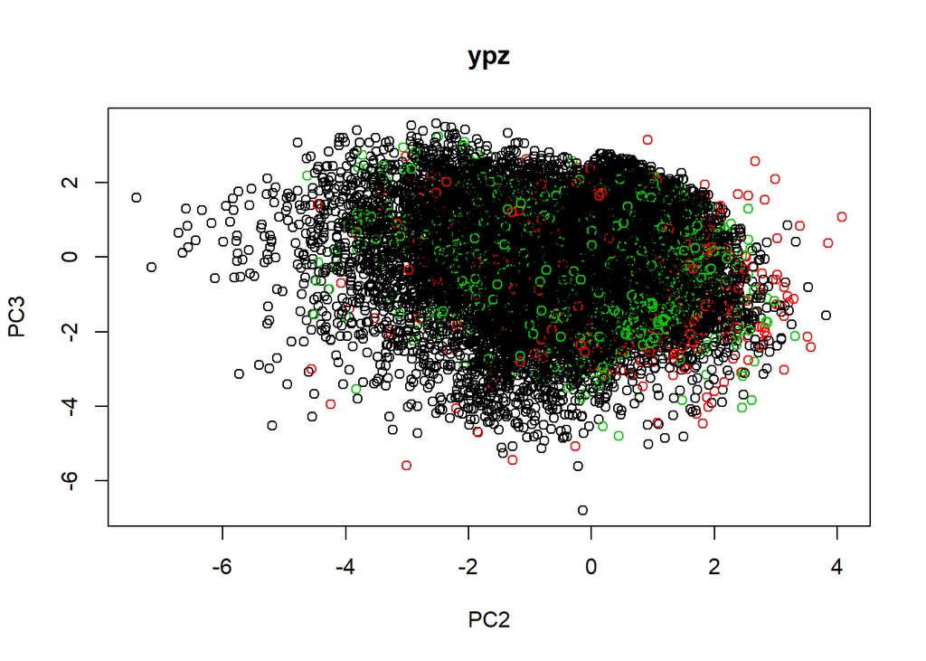

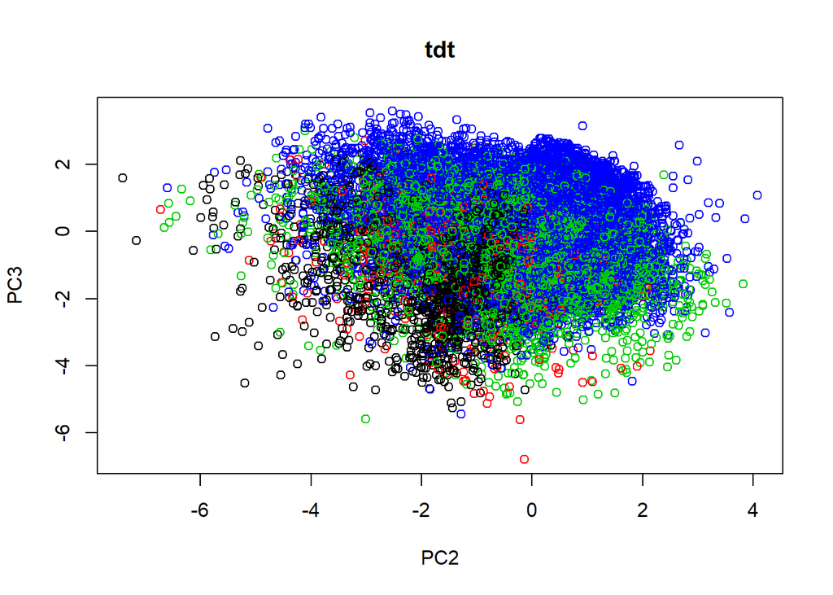

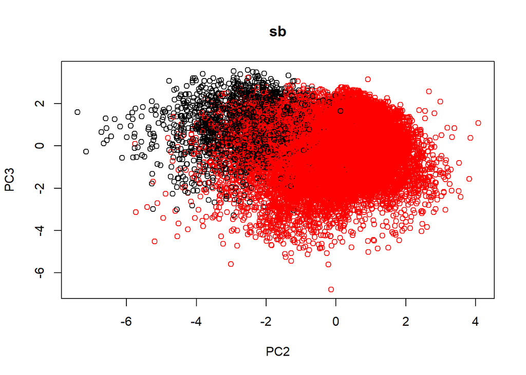

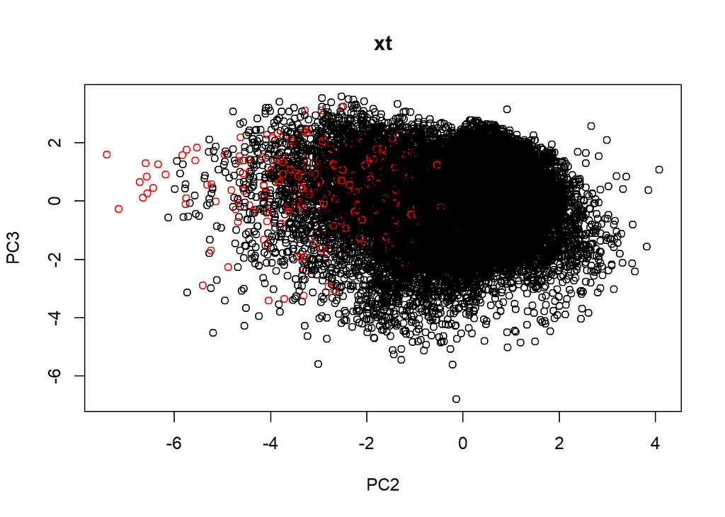

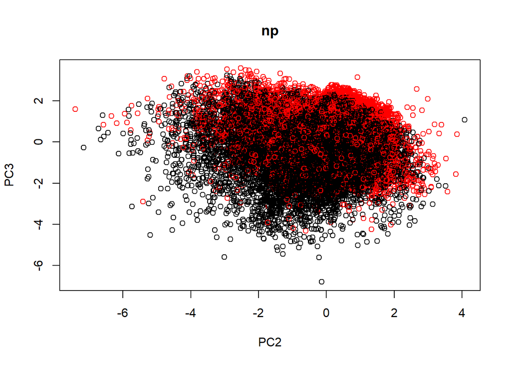

```r
for (i in discrete.vec){
    plot(pca$x[,2:3], col=pca.data[,i], main = i)
}
```

PC3 vs PC4 plots:

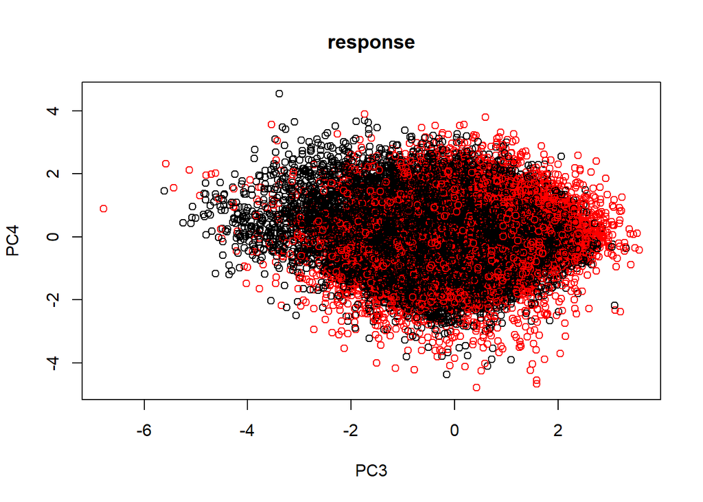

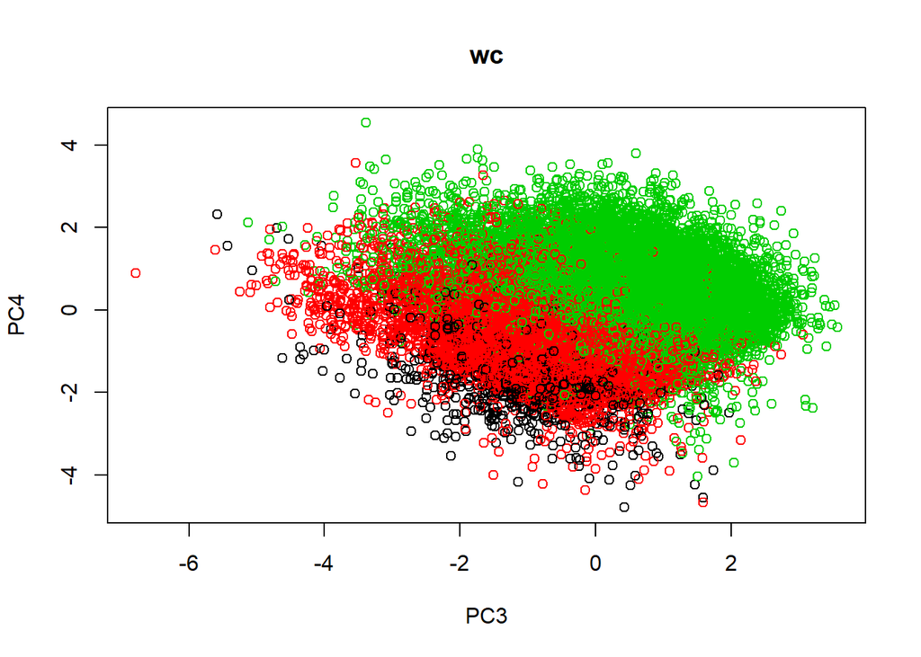

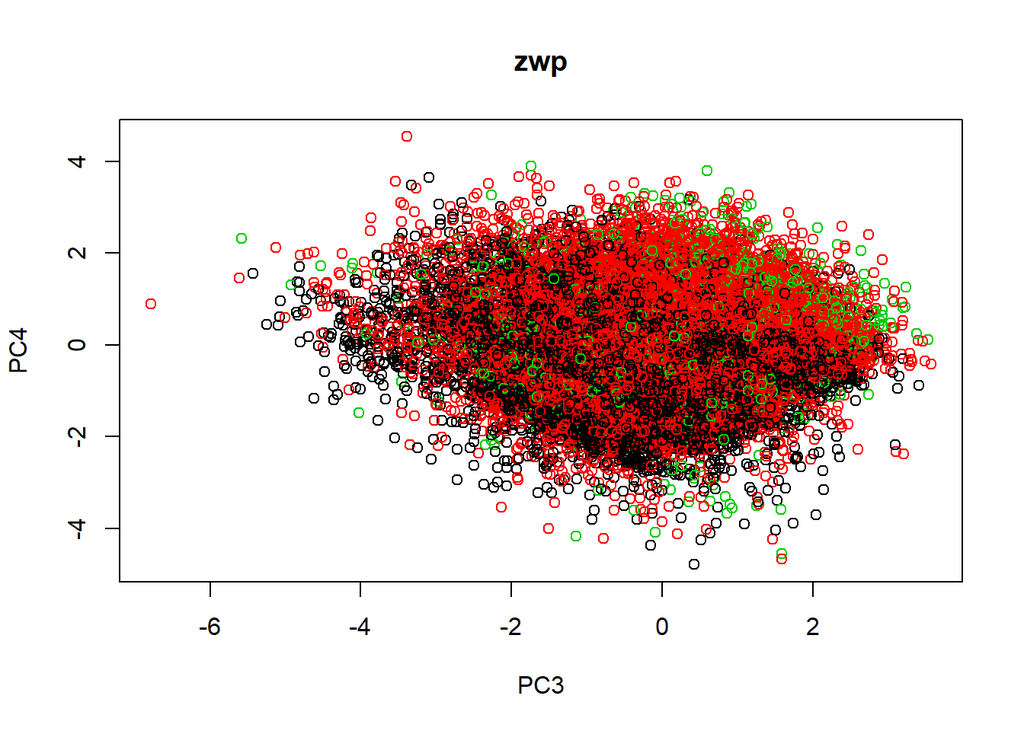

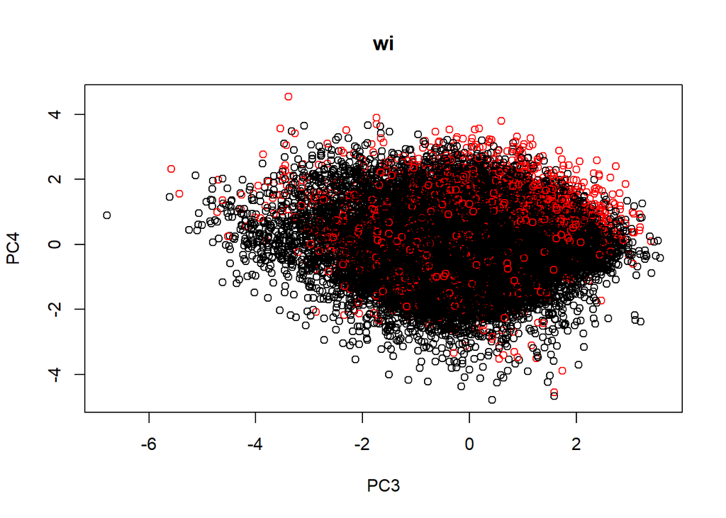

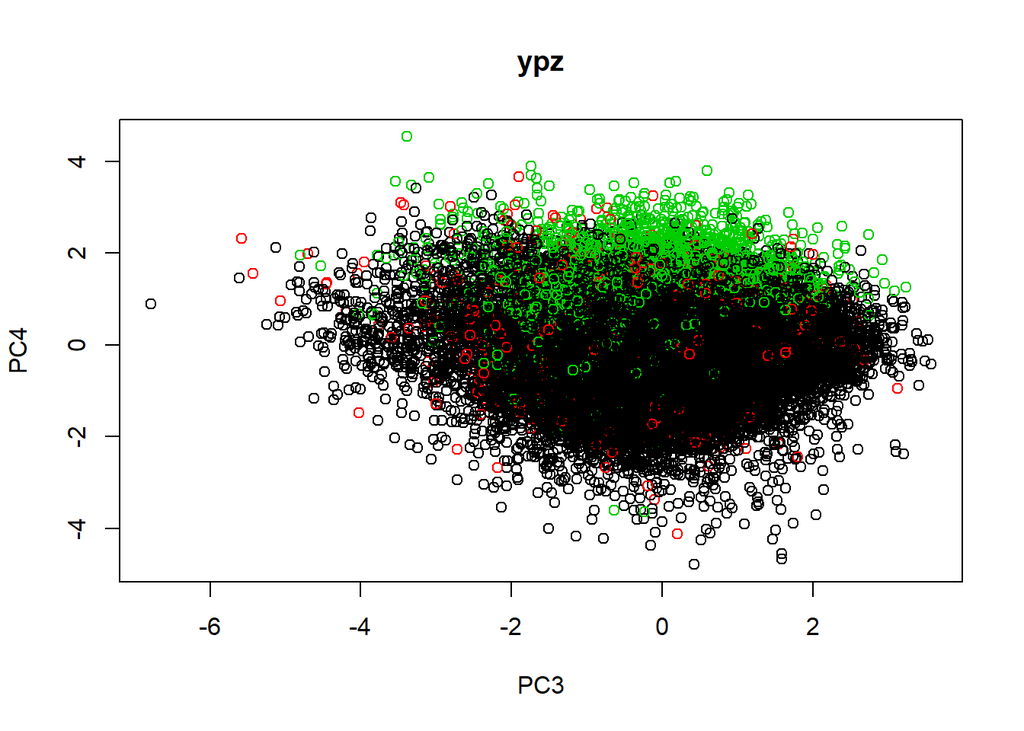

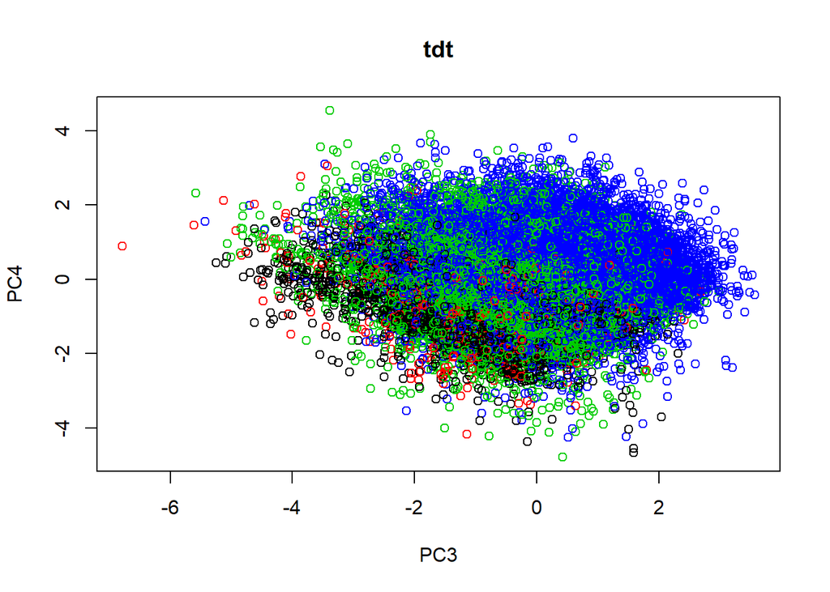

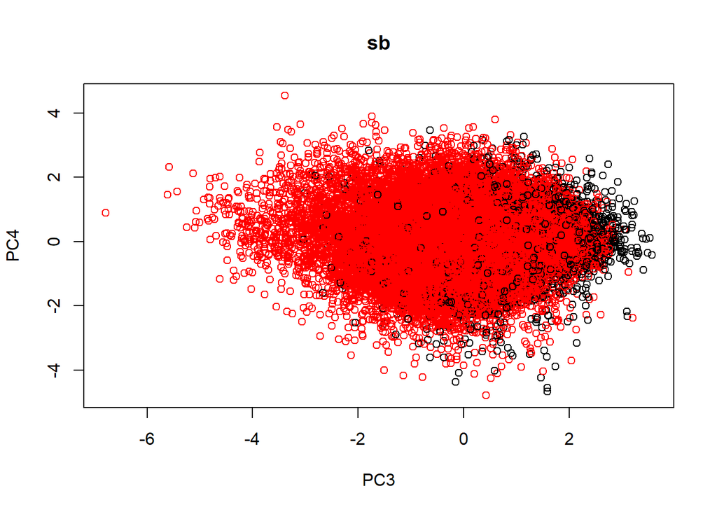

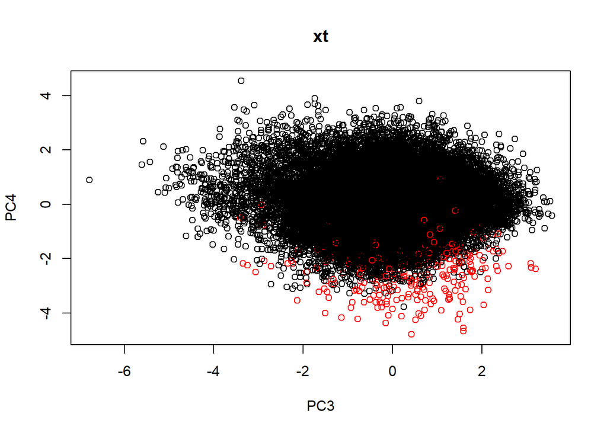

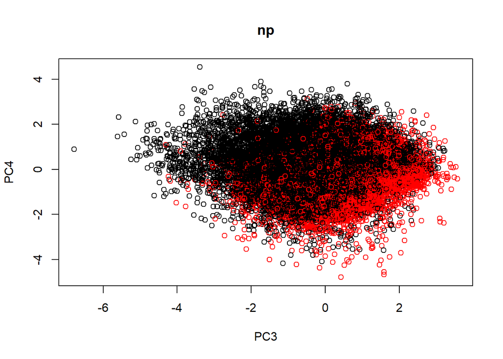

```r
for (i in discrete.vec){
    plot(pca$x[,3:4], col=pca.data[,i], main = i)
}
```

## Univariate Analysis

### Continuous Variables

T-tests:

```r
for (i in 2:7){
    print(continuous.vec[i])
    print(
        t.test(
            pp.data.1[pp.data.1$response == "Y", continuous.vec[i]],
            pp.data.1[pp.data.1$response == "N", continuous.vec[i]])
    )
}
```

```
## [1] "dtj"
##
##  Welch Two Sample t-test
##
## data:  pp.data.1[pp.data.1$response == "Y", continuous.vec[i]] and pp.data.1[pp.data.1$response == "N", continuous.vec[i]]
## t = 27.517, df = 16412, p-value < 2.2e-16
## alternative hypothesis: true difference in means is not equal to 0
## 95 percent confidence interval:
##  0.2262326 0.2609343
## sample estimates:
## mean of x mean of y
##  3.211214  2.967630
##
## [1] "qh"
##
##  Welch Two Sample t-test
##
## data:  pp.data.1[pp.data.1$response == "Y", continuous.vec[i]] and pp.data.1[pp.data.1$response == "N", continuous.vec[i]]
## t = 51.115, df = 9134.9, p-value < 2.2e-16
## alternative hypothesis: true difference in means is not equal to 0
## 95 percent confidence interval:
##  0.1723595 0.1861063
## sample estimates:
## mean of x mean of y
##  1.928520  1.749287
##
## [1] "sci"
##
##  Welch Two Sample t-test
##
## data:  pp.data.1[pp.data.1$response == "Y", continuous.vec[i]] and pp.data.1[pp.data.1$response == "N", continuous.vec[i]]
## t = 16.358, df = 10342, p-value < 2.2e-16
## alternative hypothesis: true difference in means is not equal to 0
## 95 percent confidence interval:
##  0.009679634 0.012315390
## sample estimates:
## mean of x mean of y
##  1.381108  1.370111
##
## [1] "bw"
```

[output cut: 22 more lines]

```
## mean of x mean of y
##  3.333595  2.551207
##
## [1] "is"
##
##  Welch Two Sample t-test
##
## data:  pp.data.1[pp.data.1$response == "Y", continuous.vec[i]] and pp.data.1[pp.data.1$response == "N", continuous.vec[i]]
## t = -3.777, df = 13278, p-value = 0.0001594
## alternative hypothesis: true difference in means is not equal to 0
## 95 percent confidence interval:
##  -0.12295495 -0.03893835
## sample estimates:
## mean of x mean of y
##  2.093072  2.174018
```

All variables are significant because their p-values are below 0.05. is is the least significant but it still has a p-value of 0.0001594. All others are highly significant.

### Discrete Variables

Fisher Exact Tests:

```r
for (i in discrete.vec[2:length(discrete.vec)]){
    print(i)
    print(
        fisher.test(
            table(pp.data.1$response, pp.data.1[,i]),
            workspace = 10000000))
}
```

```
## [1] "wc"
##
##  Fisher's Exact Test for Count Data
##
## data:  table(pp.data.1$response, pp.data.1[, i])
## p-value < 2.2e-16
## alternative hypothesis: two.sided
##
## [1] "zwp"
##
##  Fisher's Exact Test for Count Data
##
## data:  table(pp.data.1$response, pp.data.1[, i])
## p-value < 2.2e-16
## alternative hypothesis: two.sided
##
## [1] "wi"
##
##  Fisher's Exact Test for Count Data
##
## data:  table(pp.data.1$response, pp.data.1[, i])
## p-value < 2.2e-16
## alternative hypothesis: true odds ratio is not equal to 1
## 95 percent confidence interval:
##  14.01004 17.13971
## sample estimates:
## odds ratio
##   15.49781
##
## [1] "ypz"
##
##  Fisher's Exact Test for Count Data
##
## data:  table(pp.data.1$response, pp.data.1[, i])
## p-value < 2.2e-16
## alternative hypothesis: two.sided
##
## [1] "tdt"
##
##  Fisher's Exact Test for Count Data
```

[output cut: 28 more lines]

```
## odds ratio
##   9.641728
##
## [1] "np"
##
##  Fisher's Exact Test for Count Data
##
## data:  table(pp.data.1$response, pp.data.1[, i])
## p-value < 2.2e-16
## alternative hypothesis: true odds ratio is not equal to 1
## 95 percent confidence interval:
##  2.690117 3.016338
## sample estimates:
## odds ratio
##   2.848466
```

All variables have highly significant p-values. Note that ent and ox were already removed from the data by visual inspection. The below analysis confirms that decision because both of their p-values are above 0.01.

Double check variables previously eliminated were non-significant using the Fisher Exact Test:

```r
fisher.test(
        table(raw.data$response, raw.data$ent),
        workspace = 100000)
```

```
##
##  Fisher's Exact Test for Count Data
##
## data:  table(raw.data$response, raw.data$ent)
## p-value = 0.8161
## alternative hypothesis: true odds ratio is not equal to 1
## 95 percent confidence interval:
##  0.9283723 1.0588436
## sample estimates:
## odds ratio
##  0.9916054
```

```r
fisher.test(
        table(raw.data$response, raw.data$ox),
        workspace = 10000000)
```

```
##
##  Fisher's Exact Test for Count Data
##
## data:  table(raw.data$response, raw.data$ox)
## p-value = 0.05336
## alternative hypothesis: two.sided
```

```r
fisher.test(
        table(raw.data$response, raw.data$bnf),
        workspace = 10000000, simulate.p.value = TRUE)
```

```
##
##  Fisher's Exact Test for Count Data with simulated p-value (based on
##  2000 replicates)
##
## data:  table(raw.data$response, raw.data$bnf)
## p-value = 0.0004998
## alternative hypothesis: two.sided
```

Although the p-value for bnf is significant, comparitively the other categorical values are much more significant. I removed this variable from consideration.

## Exploratory Conclusions

1. qh and np are the strongest continuous predictor based on the scatterplots are success rates. Using qh plotted against any other continuous variable and coloring the points by np shows strong groupings that match fairly closely to the response variable. Per the contingency table, using np by itself as a predictor has an accuracy over 70%.
2. The following categorical variables had their number of levels reduced and combined. This will revent rare occurance treatments from skewing the model. The methodology was to target treatments with similar success rates that accounted for less than 5% of the number of observations and then combine those.

wc: combine a/c/f; combine b/e; make 3 levels zwp: combine S/R; combine T/O/U/N; combine V/X/W/Q/Y/P/Z; make 3 levels ypz: combine 1/4/11/0/6/14/7; combine 3/12/10; combine 15/19/16; combine 17/13/5/8/2; make 4 levels sb: combine sb into s2/s5 and not s2/s5; make 2 levels xt: combine dgk/ntb/fcc; combine mrm/gcn; make 2 levels

3. Although ku was a factor type of data, I converted it to continuous because of the obvious linear pattern in the its success rate chart. Linearity can also be seen in scatter plots of ku versus other continuous variables.
4. ypz was an integer type of data however I converted it to a factor because of its bimodality and non-apparent linear treand in its histogram and pair plots. The remaining numeric types of data were analyzed using histograms and pair plots to ensure normality and linearity.
5. ent, bnf and ox were found to have no significant impact and/or a potential to skew the results on the response and therefore they were eliminated. This was done visually and then confirmed with a fisher exact test.
6. After exploratory analysis and preprocessing I am moving forward with 6 continuous variables:

```r
continuous.vec[2:length(continuous.vec)]
```

```
## [1] "dtj" "qh"  "sci" "bw"  "ku"  "is"
```

```r
summary(pp.data.1[,2:7])
```

```
##       dtj              qh             sci              bw
##  Min.   :0.000   Min.   :1.310   Min.   :1.110   Min.   :0.1414
##  1st Qu.:2.828   1st Qu.:1.661   1st Qu.:1.351   1st Qu.:0.3162
##  Median :3.317   Median :1.752   Median :1.371   Median :0.3742
##  Mean   :3.028   Mean   :1.793   Mean   :1.373   Mean   :0.3760
##  3rd Qu.:3.606   3rd Qu.:1.882   3rd Qu.:1.396   3rd Qu.:0.4000
##  Max.   :3.742   Max.   :4.721   Max.   :1.592   Max.   :1.2649
##        ku              is
##  Min.   :1.000   Min.   : 0.00011
##  1st Qu.:1.000   1st Qu.: 0.86299
##  Median :2.000   Median : 1.80825
##  Mean   :2.744   Mean   : 2.15407
##  3rd Qu.:4.000   3rd Qu.: 3.08935
##  Max.   :8.000   Max.   :16.02500
```

…and 8 categorical variables:

```r
discrete.vec[2:length(discrete.vec)]
```

```
## [1] "wc"  "zwp" "wi"  "ypz" "tdt" "sb"  "xt"  "np"
```

```r
summary(pp.data.1[,8:15])
```

```
##    wc             zwp          wi                     ypz        tdt
##  acf: 1325   SR     :13923   gmz:28424   1,4,11,0,6,14,7:27941   kc: 3392
##  be :10866   TOUN   :15433   gnq: 2570   17,13,5,8,2    :  673   kv: 1024
##  d  :18803   VXWQYPZ: 1638               3,12,10        : 2380   sm: 9597
##                                                                  zp:16981
##             sb                  xt        np
##  s1s3s4s6s7s8: 2148   dgk,ntb,fcc:30661   j:23792
##  s2s5        :28846   mrm,gcn    :  333   k: 7202
##
##
```

8. The PCA analysis required the data to be scaled and centered as well as the categorical values to be converted to numeric. The scaling and center was required to accuratley compare variables on different scales and center points.
9. Clearly the data cannot be predicted very well using a univariate model. It is complex and needs to leverage several predictors.

# Problem 2: logistic regression (20 points)

Develop logistic regression model of the outcome `response` as a function of multiple predictors in the model. Which variables are significantly associated with the outcome? Test model performance on multiple splits of data into training and test subsets and summarize it in terms of accuracy/error/sensitivity/specificity.

## Variable Selection

I am choosing lasso regression to evaluate the most impactful variables because ridge seemed to be overfitting significantly. The ridge/lasso method will also allow me to use categorical values.

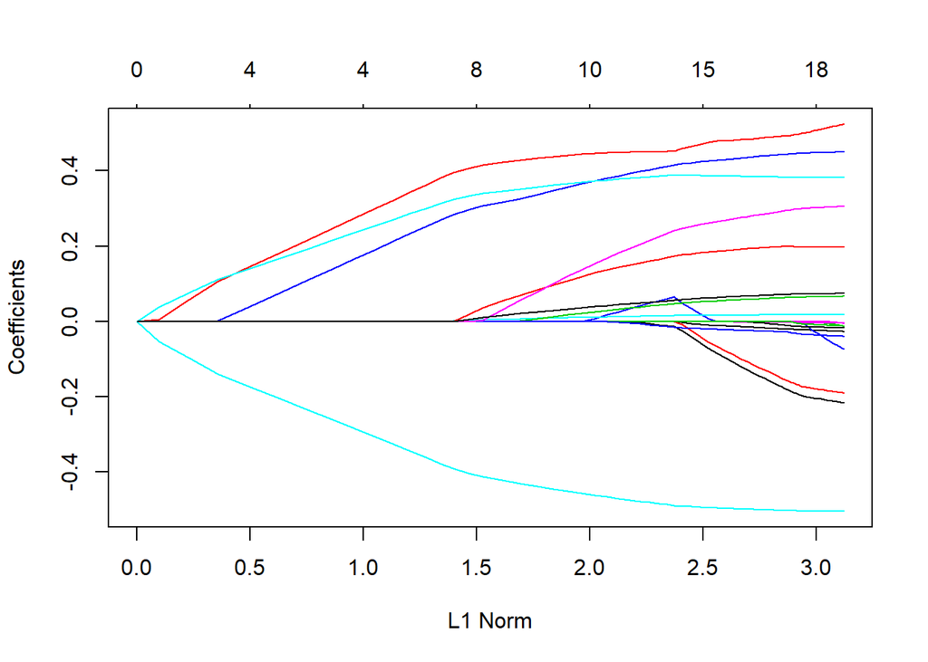

```r
# Perform lasso regression
lasso <- model.matrix(response~., pp.data.1)[,-1]
lasso.response <- as.numeric(pp.data.1$response)
lasso.reg <- glmnet(lasso, lasso.response, alpha = 1)
plot(lasso.reg)
```

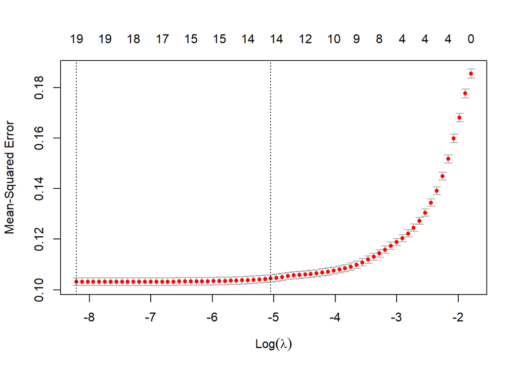

```r
cvlassoRes <- cv.glmnet(lasso, lasso.response, alpha=1)
plot(cvlassoRes)
```

```r
log(cvlassoRes$lambda.1se)
```

```
## [1] -5.048906
```

```r
cvlassoRes$lambda.1se
```

```
## [1] 0.00641635
```

Using the 1 SE method reduces the possibility of overfitting.

```r
predict(lasso.reg,type="coefficients",s=cvlassoRes$lambda.1se)
```

```
## 20 x 1 sparse Matrix of class "dgCMatrix"
##                            1
## (Intercept)     0.8007028083
## dtj            -0.0091631183
## qh              0.4753918642
## sci             .
## bw              0.0063869790
## ku              0.0161212987
## is             -0.0002520017
## wcbe           -0.0726262656
## wcd            -0.0546669515
## zwpTOUN         0.0533293726
## zwpVXWQYPZ      0.4265055590
## wignq           0.3868646959
## ypz17,13,5,8,2  .
## ypz3,12,10      .
## tdtkv           0.1845825506
## tdtsm           .
## tdtzp          -0.0201182573
## sbs2s5         -0.4944330368
## xtmrm,gcn       0.2619270696
## npk             0.0624611148
```

```r
sort(abs(predict(lasso.reg,type="coefficients",s=cvlassoRes$lambda.1se)[,1]),
     decreasing = TRUE)
```

```
##    (Intercept)         sbs2s5             qh     zwpVXWQYPZ          wignq
##   0.8007028083   0.4944330368   0.4753918642   0.4265055590   0.3868646959
##      xtmrm,gcn          tdtkv           wcbe            npk            wcd
##   0.2619270696   0.1845825506   0.0726262656   0.0624611148   0.0546669515
##        zwpTOUN          tdtzp             ku            dtj             bw
##   0.0533293726   0.0201182573   0.0161212987   0.0091631183   0.0063869790
##             is            sci ypz17,13,5,8,2     ypz3,12,10          tdtsm
##   0.0002520017   0.0000000000   0.0000000000   0.0000000000   0.0000000000
```

```r
select.data <- pp.data.1
select.data$sci <- NULL
select.data$bw <- NULL
select.data$ypz <- NULL
head(select.data)
```

```
##        response     dtj       qh ku      is wc     zwp  wi tdt   sb          xt
## 165931        N 3.31662 1.619306  2 0.24077  d      SR gnq  kc s2s5 dgk,ntb,fcc
## 241964        N 0.00000 1.465870  8 3.76180 be      SR gmz  sm s2s5 dgk,ntb,fcc
## 387089        Y 3.46410 2.011248  4 2.49990 be    TOUN gmz  zp s2s5 dgk,ntb,fcc
## 433922        Y 3.31662 1.915616  3 2.47710 be VXWQYPZ gmz  sm s2s5 dgk,ntb,fcc
## 175120        N 3.74166 1.740224  1 4.17080 be      SR gmz  zp s2s5 dgk,ntb,fcc
## 353214        N 2.23607 1.656426  1 2.94250 be      SR gmz  zp s2s5 dgk,ntb,fcc
##        np
## 165931  j
## 241964  j
## 387089  j
## 433922  k
## 175120  j
## 353214  j
```

## Logistic Regression

```r
glm.fit <- glm(response~., data=select.data, family=binomial)
summary(glm.fit)
```

```
##
## Call:
## glm(formula = response ~ ., family = binomial, data = select.data)
##
## Deviance Residuals:
##     Min       1Q   Median       3Q      Max
## -4.2975  -0.4706  -0.3300  -0.1859   2.8945
##
## Coefficients:
##              Estimate Std. Error z value Pr(>|z|)
## (Intercept) -4.079588   0.202354 -20.161  < 2e-16 ***
## dtj         -0.106280   0.031843  -3.338 0.000845 ***
## qh           3.817672   0.115847  32.954  < 2e-16 ***
## ku           0.159403   0.009288  17.162  < 2e-16 ***
## is          -0.040418   0.011252  -3.592 0.000328 ***
## wcbe        -1.928740   0.087923 -21.937  < 2e-16 ***
## wcd         -1.654247   0.084639 -19.545  < 2e-16 ***
## zwpTOUN      0.662967   0.039566  16.756  < 2e-16 ***
## zwpVXWQYPZ   3.366134   0.080691  41.716  < 2e-16 ***
## wignq        2.662586   0.062062  42.902  < 2e-16 ***
## tdtkv        1.461720   0.104783  13.950  < 2e-16 ***
## tdtsm       -0.100814   0.075041  -1.343 0.179128
## tdtzp       -0.338766   0.071203  -4.758 1.96e-06 ***
## sbs2s5      -3.591509   0.072715 -49.391  < 2e-16 ***
## xtmrm,gcn    2.625036   0.158205  16.593  < 2e-16 ***
## npk          0.603966   0.042309  14.275  < 2e-16 ***
## ---
## Signif. codes:  0 '***' 0.001 '**' 0.01 '*' 0.05 '.' 0.1 ' ' 1
##
## (Dispersion parameter for binomial family taken to be 1)
##
##     Null deviance: 34613  on 30993  degrees of freedom
## Residual deviance: 20041  on 30978  degrees of freedom
## AIC: 20073
##
## Number of Fisher Scoring iterations: 5
```

The logistic regression model agrees with the lasso analysis about the relative importance of the variables. Certain levels of tdt are insignificant. Other levels of that variable is however so it must stay in the model.

```r
sort(abs(glm.fit$coefficients[2:length(glm.fit$coefficients)]), decreasing = TRUE, index.return = TRUE)$x
```

```
##         qh     sbs2s5 zwpVXWQYPZ      wignq  xtmrm,gcn       wcbe        wcd
## 3.81767204 3.59150854 3.36613406 2.66258591 2.62503557 1.92874005 1.65424742
##      tdtkv    zwpTOUN        npk      tdtzp         ku        dtj      tdtsm
## 1.46171952 0.66296728 0.60396573 0.33876588 0.15940322 0.10628008 0.10081393
##         is
## 0.04041839
```

Generate the predictions on the full data set:

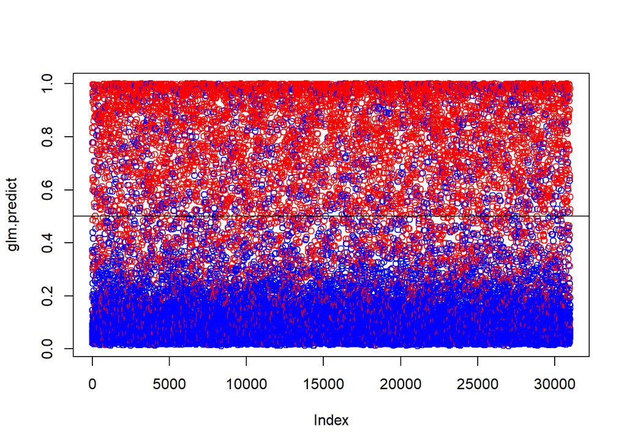

```r
glm.predict <- predict(glm.fit, newdata=select.data, type = "response")
plot(glm.predict, col = ifelse(as.numeric(select.data$response) == 1, "blue", "red"))
abline(h=0.5)
```

Generate predictions on test/train splits:

```r
#specify number of samples
nrep <- 500
fence <- 0.5

#create storage
error.rate = numeric()
accuracy = numeric()
sensitivity = numeric()
specificity = numeric()

#sample loop
for ( i in 1:nrep){

    #split into test/train
    test.row.sample <- sample(seq(1,nrow(select.data)),
                              ceiling(.3 * nrow(select.data)),
                              replace = FALSE)
    test.split <- select.data[test.row.sample,]
    train.split <- select.data[-test.row.sample,]

    #fit and prdict the logistic regression model
    glm.fit <- glm(response~., data=train.split, family=binomial)
    glm.predict <- predict(glm.fit, newdata=test.split, type = "response")

    #prediction post processing
    glm.predict[glm.predict >= fence] <- 1 #force variable to 0/1
    glm.predict[glm.predict < fence] <- 0 #force variable to 0/1
    predicted <- glm.predict

    #compputing performance of the model
    truth <- as.numeric(test.split$response) - 1
    TP = sum(truth==1 & predicted==1)
    TN = sum(truth==0 & predicted==0)
    FP = sum(truth==0 & predicted==1)
    FN = sum(truth==1 & predicted==0)
    P = TP+FN
    N = FP+TN
    error.rate[i] <- 100-(signif(sum(truth==predicted)*100/length(truth),3))
    accuracy[i] <- (signif(sum(truth==predicted)*100/length(truth),3))
    sensitivity[i] <- signif(100*TP/P,3)
    specificity[i] <- signif(100*TN/N,3)
}

logistic.performance <- cbind(error.rate, accuracy, sensitivity, specificity)
logistic.performance.mean <- as.data.frame(apply(logistic.performance, 2, mean))
colnames(logistic.performance.mean) <- paste0(nrep, "rep.logistic.mean")
logistic.performance.mean
```

```
##             500rep.logistic.mean
## error.rate               11.6448
## accuracy                 88.3552
## sensitivity              65.6288
## specificity              95.7828
```

## Extra points problem: interaction terms (5 extra points)

Assess the impact/significance of pairwise interaction terms for all pairwise combinations of covariates used in the model and report the top ten that most significantly improve model fit.

# Problem 3: linear discriminant analysis (15 points)

Fit linear discriminant analysis model of the outcome `response` as a function of the rest of covariates in the dataset. Feel free to decide whether you want to use all of them or a subset of those. Test resulting model performance on multiple splits of the data into training and test subsets, summarize it in terms of accuracy/error/sensitivity/specificity and compare them to those obtained for logistic regression.

```r
#test
lda.fit <- lda(response~., data=select.data)
lda.predict <- predict(lda.fit, newdata = select.data[,2:ncol(select.data)])
predicted <- lda.predict$class
lda.fit
```

```
## Call:
## lda(response ~ ., data = select.data)
##
## Prior probabilities of groups:
##         N         Y
## 0.7535652 0.2464348
##
## Group means:
##        dtj       qh       ku       is      wcbe       wcd   zwpTOUN zwpVXWQYPZ
## N 2.967630 1.749287 2.551207 2.174018 0.3653023 0.6186847 0.4735400 0.01297311
## Y 3.211214 1.928520 3.333595 2.093072 0.3055774 0.5699136 0.5725321 0.17478397
##        wignq      tdtkv     tdtsm     tdtzp    sbs2s5   xtmrm,gcn       npk
## N 0.02290632 0.01969515 0.2915739 0.5650796 0.9868128 0.003510875 0.1816664
## Y 0.26643100 0.07384132 0.3648861 0.4952867 0.7590992 0.032862006 0.3874051
##
## Coefficients of linear discriminants:
##                    LD1
## dtj        -0.11422678
## qh          2.35219849
## ku          0.08371365
## is         -0.01902030
## wcbe       -1.04527268
## wcd        -0.91995642
## zwpTOUN     0.30978640
## zwpVXWQYPZ  2.10463140
## wignq       1.77891277
## tdtkv       0.89735386
## tdtsm      -0.08991610
## tdtzp      -0.21100610
## sbs2s5     -2.35795319
## xtmrm,gcn   1.43345606
## npk         0.34860263
```

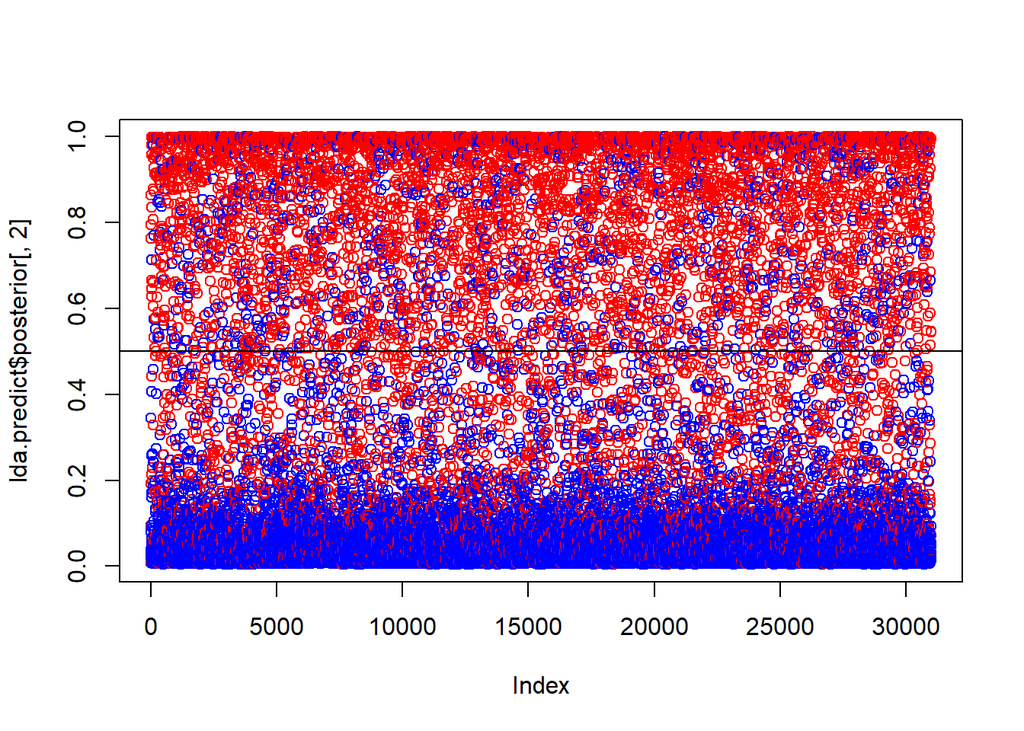

```r
plot(lda.predict$posterior[,2], col = ifelse(as.numeric(select.data$response) == 1, "blue", "red"))
abline(h=0.5)
```

Variable influence on the model:

```r
abs(lda.fit$scaling)
```

```
##                   LD1
## dtj        0.11422678
## qh         2.35219849
## ku         0.08371365
## is         0.01902030
## wcbe       1.04527268
## wcd        0.91995642
## zwpTOUN    0.30978640
## zwpVXWQYPZ 2.10463140
## wignq      1.77891277
## tdtkv      0.89735386
## tdtsm      0.08991610
## tdtzp      0.21100610
## sbs2s5     2.35795319
## xtmrm,gcn  1.43345606
## npk        0.34860263
```

```r
sort(abs(lda.fit$scaling), decreasing = TRUE, index.return=TRUE)$x
```

```
##  [1] 2.35795319 2.35219849 2.10463140 1.77891277 1.43345606 1.04527268
##  [7] 0.91995642 0.89735386 0.34860263 0.30978640 0.21100610 0.11422678
## [13] 0.08991610 0.08371365 0.01902030
```

```r
#specify number of samples
nrep <- 500

#create storage
error.rate = numeric()
accuracy = numeric()
sensitivity = numeric()
specificity = numeric()

#sample loop
for ( i in 1:nrep){

    #split into test/train
    test.row.sample <- sample(seq(1,nrow(select.data)),
                              ceiling(.3 * nrow(select.data)),
                              replace = FALSE)
    test.split <- select.data[test.row.sample,]
    train.split <- select.data[-test.row.sample,]

    #fit and prdict the lda regression model
    lda.fit <- lda(response~., data=train.split)
    lda.predict <- predict(lda.fit, newdata = test.split[,2:ncol(test.split)])
    predicted <- as.numeric(lda.predict$class) - 1

    #compputing performance of the model
    truth <- as.numeric(test.split$response) - 1
    TP = sum(truth==1 & predicted==1)
    TN = sum(truth==0 & predicted==0)
    FP = sum(truth==0 & predicted==1)
    FN = sum(truth==1 & predicted==0)
    P = TP+FN
    N = FP+TN
    error.rate[i] <- 100-(signif(sum(truth==predicted)*100/length(truth),3))
    accuracy[i] <- (signif(sum(truth==predicted)*100/length(truth),3))
    sensitivity[i] <- signif(100*TP/P,3)
    specificity[i] <- signif(100*TN/N,3)
}

# results
lda.performance <- cbind(error.rate, accuracy, sensitivity, specificity)
lda.performance.mean <- as.data.frame(apply(lda.performance, 2, mean))
colnames(lda.performance.mean) <- paste0(nrep, "rep.lda.mean")
```

Compare LDA and Logistic Regression Performance:

```r
compare.table1 <- cbind(logistic.performance.mean, lda.performance.mean)
compare.table1
```

```
##             500rep.logistic.mean 500rep.lda.mean
## error.rate               11.6448         12.3364
## accuracy                 88.3552         87.6636
## sensitivity              65.6288         61.8632
## specificity              95.7828         96.1156
```

The accuracy is slightly lower for the LDA model than the logistic regression. The LDA model has a slightly lower sensitivity but a slightly higher specificty.

# Problem 4: random forest (15 points)

Develop random forest model of outcome `response`. Present variable importance plots and comment on relative importance of different attributes in the model. Did attributes showing up as more important in random forest model also appear as significantly associated with the outcome by logistic regression? Test model performance on multiple splits of data into training and test subsets, compare test and out-of-bag error estimates, summarize model performance in terms of accuracy/error/sensitivity/specificity and compare to the performance of logistic regression and LDA models above.

```r
rfRes <- randomForest(select.data[1:22000,2:ncol(select.data)],
                      select.data[1:22000,"response"],
                      mtry = 5, ntree = 1000, importance = TRUE)
rfTmpTbl <- table(select.data[22001:nrow(select.data),"response"],
                  predict(
                      rfRes,
                      newdata=select.data[22001:nrow(select.data),2:ncol(select.data)]))
rfTmpTbl
```

```
##
##        N    Y
##   N 6400  399
##   Y  581 1614
```

```r
err=100*(1-sum(diag(rfTmpTbl))/sum(rfTmpTbl))
cat("Error Rate:",err)
```

```
## Error Rate: 10.89615
```

```r
cat("\nAccuracy:",100 - err,"\n")
```

```
##
## Accuracy: 89.10385
```

```r
print("Rank of Variable Importance")
```

```
## [1] "Rank of Variable Importance"
```

```r
sort(rfRes$importance[,3], decreasing = TRUE)
```

```
##           qh           sb           wi          zwp          dtj           wc
## 0.0539633067 0.0515525893 0.0444628341 0.0378018545 0.0177857940 0.0148950443
##           ku          tdt           np           xt           is
## 0.0138351120 0.0116216597 0.0073723513 0.0045195269 0.0003097233
```

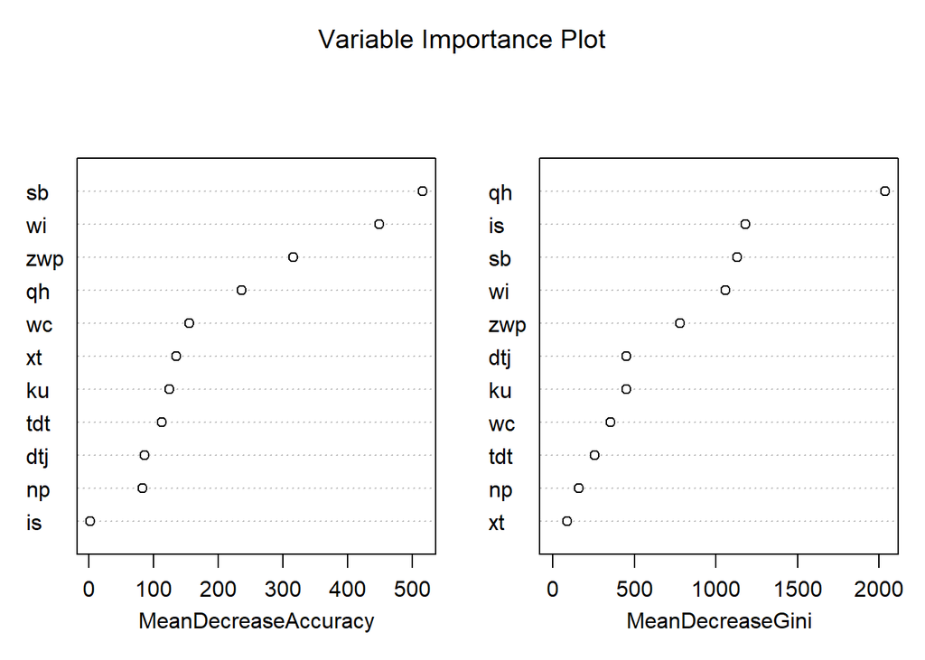

```r
varImpPlot(rfRes, main = "Variable Importance Plot")
```

mtry and ntrees were tuned. Values of mtry used were 2-10. The optimal value was selected as 5. Values of ntrees used were 500-2000. The optimal value was selected as 1000.

```r
# Fit random forest to train data, obtain test error:
rf.generator <- function( train.data, train.labels, test.data, test.labels,...){
  rfRes <- randomForest(train.data,train.labels,importance = TRUE, ...)
  rfPred <- predict(rfRes,newdata=test.data)
  rfTmpTbl <- table(test.labels,rfPred)
  #list of items to return from the function:
  ret.list <- list("model" = rfRes, "prediction.table" = rfTmpTbl,
                   "predictions" = rfPred, "oob.err" = min(rfRes$err.rate[,1]),
                   "importance" = sort(rfRes$importance[,3], decreasing = TRUE))
  return(ret.list)
}

#specify the runs and hyperparameters
nrep <- 20
mtry.go <- 5
ntrees.go <- 1000

#create storage
error.rate = numeric()
oob.err.rate = numeric()
rf.importance <- NULL
accuracy = numeric()
sensitivity = numeric()
specificity = numeric()
importance.order <- names(select.data[,2:ncol(select.data)])

#sample loop
for ( i in 1:nrep){

    #split into test/train
    test.row.sample <- sample(seq(1,nrow(select.data)),
                              ceiling(.3 * nrow(select.data)),
                              replace = FALSE)
    test.split <- select.data[test.row.sample,]
    train.split <- select.data[-test.row.sample,]

    #fit and predict random forest model
    rf <- rf.generator(train.split[,2:ncol(train.split)], train.split$response,
                        test.split[,2:ncol(test.split)], test.split$response,
                       mtry = mtry.go,
                       ntree = ntrees.go)
    predicted <- as.numeric(rf$predictions) - 1

    #computing performance of the model
    truth <- as.numeric(test.split$response) - 1
    TP = sum(truth==1 & predicted==1)
    TN = sum(truth==0 & predicted==0)
    FP = sum(truth==0 & predicted==1)
    FN = sum(truth==1 & predicted==0)
    P = TP+FN
    N = FP+TN
    oob.err.rate[i] <- rf$oob.err * 100
    rf.importance <- rbind(rf.importance, rf$importance[importance.order])
    error.rate[i] <- 100 *
        (1-sum(diag(rf$prediction.table))/sum(rf$prediction.table))
    accuracy[i] <- 100 - error.rate[i]
    sensitivity[i] <- signif(100*TP/P,3)
    specificity[i] <- signif(100*TN/N,3)
}

# oob to test error results
rf.err.compare <- cbind(error.rate, oob.err.rate)
rf.err.compare.mean <- as.data.frame(apply(rf.err.compare, 2, mean))
colnames(rf.err.compare.mean) <- paste0(nrep, "rep.rf.mean")

# importance
rf.importance.mean <- as.data.frame(apply(rf.importance, 2, mean))
colnames(rf.importance.mean) <- paste0(nrep, "rep.rf.mean")

# model to model results
rf.performance <- cbind(error.rate, accuracy, sensitivity, specificity)
rf.performance.mean <- as.data.frame(apply(rf.performance, 2, mean))
colnames(rf.performance.mean) <- paste0(nrep, "rep.rf.mean")
```

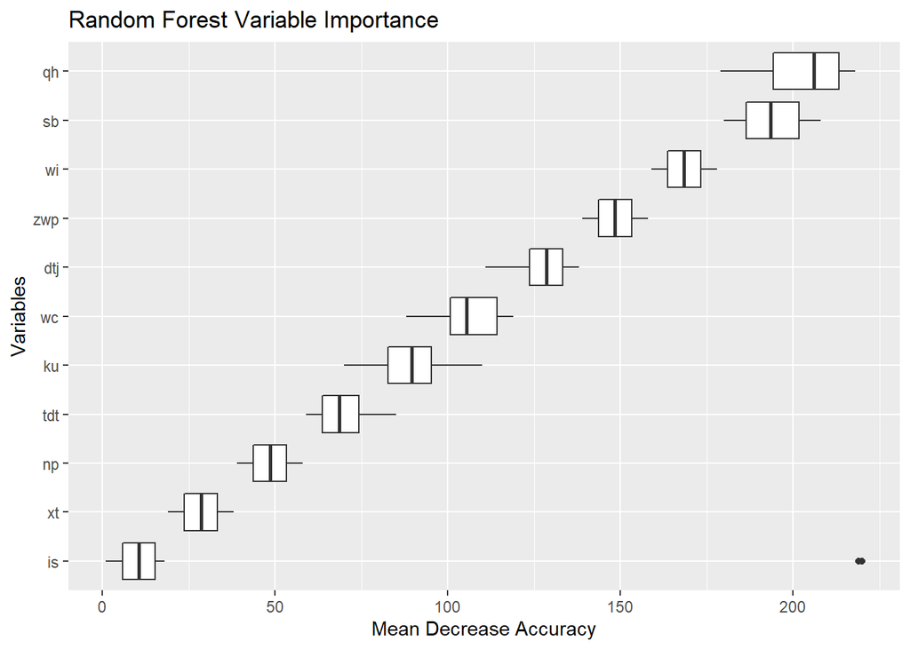

```r
importance.labels <- c(
    rep(importance.order[1],nrep),
    rep(importance.order[2],nrep),
    rep(importance.order[3],nrep),
    rep(importance.order[4],nrep),
    rep(importance.order[5],nrep),
    rep(importance.order[6],nrep),
    rep(importance.order[7],nrep),
    rep(importance.order[8],nrep),
    rep(importance.order[9],nrep),
    rep(importance.order[10],nrep),
    rep(importance.order[11],nrep)
)

rf.melt.importance <- c(
    rf.importance[,1],
    rf.importance[,2],
    rf.importance[,3],
    rf.importance[,4],
    rf.importance[,5],
    rf.importance[,6],
    rf.importance[,7],
    rf.importance[,8],
    rf.importance[,9],
    rf.importance[,10],
    rf.importance[,11]
)

rf.melt.importance <- as.data.frame(cbind(importance.labels, rf.melt.importance))
colnames(rf.melt.importance) <- c("var","MeanDecreaseAccuracy")

ggplot(rf.melt.importance, aes(x=reorder(var,as.numeric(MeanDecreaseAccuracy), median), y=as.numeric(MeanDecreaseAccuracy))) +
    geom_boxplot() +
    ggtitle("Random Forest Variable Importance") +
    xlab("Variables") + ylab("Mean Decrease Accuracy") +
    coord_flip()
```

Compare to the logistic regression order of importance below:

```r
#logistic regression ranked order of variable importance
glm.order.importance <- as.data.frame(names(sort(abs(glm.fit$coefficients[2:length(glm.fit$coefficients)]), decreasing = TRUE, index.return = TRUE)$x))
colnames(glm.order.importance) <- "variable"
glm.order.importance
```

```
##      variable
## 1          qh
## 2      sbs2s5
## 3  zwpVXWQYPZ
## 4   xtmrm,gcn
## 5       wignq
## 6        wcbe
## 7         wcd
## 8       tdtkv
## 9     zwpTOUN
## 10        npk
## 11      tdtzp
## 12         ku
## 13      tdtsm
## 14        dtj
## 15         is
```

```r
rf.err.compare.mean
```

```
##              20rep.rf.mean
## error.rate        10.79417
## oob.err.rate      10.80295
```

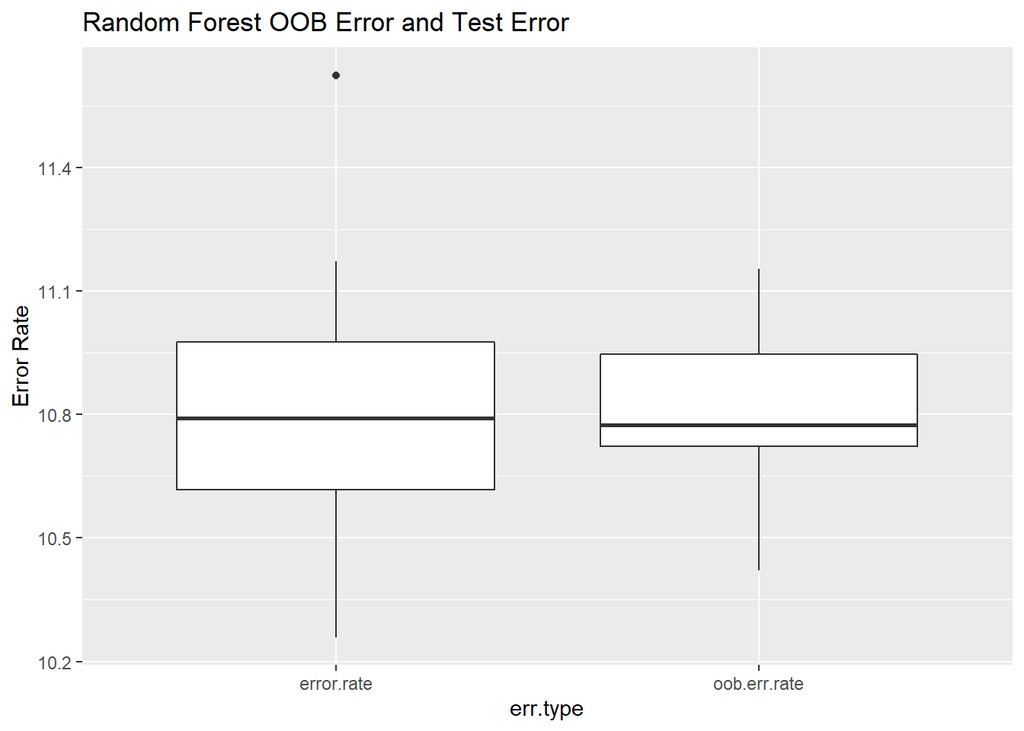

```r
rf.melt.err <- c(rf.err.compare[,1],rf.err.compare[,2])
rf.err.labels <- c(
        rep("error.rate",nrep),
        rep("oob.err.rate",nrep))

rf.melt.err <- as.data.frame(cbind(rf.err.labels,rf.melt.err))
colnames(rf.melt.err) <- c("err.type", "err.rate")

ggplot(rf.melt.err, aes(x=err.type, y=as.numeric(as.character(err.rate)))) +
    geom_boxplot() +
    ggtitle("Random Forest OOB Error and Test Error") +
    ylab("Error Rate")
```

Compare the model’s performance:

```r
compare.table2 <- cbind(compare.table1, rf.performance.mean)
compare.table2
```

```
##             500rep.logistic.mean 500rep.lda.mean 20rep.rf.mean
## error.rate               11.6448         12.3364      10.79417
## accuracy                 88.3552         87.6636      89.20583
## sensitivity              65.6288         61.8632      74.32000
## specificity              95.7828         96.1156      94.09000
```

The random forest outperforms the previous two models in accuracy by about 1 to 2%. It has a significantly higher sensitivity than both as well. I performs slightly lower than the other two in terms of specificity. This is the best model so far.